# Clase 7. Aplicacion AR(p)

Series de Tiempo | Semestre 2027-I | FC-UNAM

Benjamin Oliva & Omar Alfaro-Rivera

julio 2026

## ¿Qué aprenderemos hoy?

Generalizamos el análisis autorregresivo al caso de orden p arbitrario. El reto principal es la selección del orden: combinamos la inspección de la FACP con criterios de información (AIC y BIC) para encontrar el modelo más parsimonioso.

Al terminar esta clase deberás poder:

1. Usar la FACP para identificar visualmente el orden de un proceso AR(p)
2. Seleccionar el orden óptimo comparando modelos por AIC y BIC
3. Interpretar la diferencia entre AIC y BIC como un balance entre ajuste y parsimonia

**Datos:** `Base_Transporte.xlsx` (INEGI, transporte aéreo y metro CDMX, frecuencia mensual)

# Importamos Datos:

Los datos importados son:

- Pax_Nal: Pasajeros (Salidas) en vuelos nacionales
- Pax_Int: Pasajeros (Salidas) en vuelos internacionales
- Vue_Nal: Vuelos u operaciones (Salidas) en vuelos nacionales
- Vue_Int: Vuelos u operaciones (Salidas) en vuelos internacionales
- Pax_Metro: Pasajeros transportados (Millones) en el SCM

Fuente: INEGI, https://www.inegi.org.mx/app/indicadores/?tm=0&t=1090

```r
Datos <- read_excel("../data/Base_Transporte.xlsx", sheet = "Datos", col_names = TRUE)

tail(Datos)
```

```
## # A tibble: 6 × 6
##   Periodo             Pax_Nal Pax_Int Vue_Nal Vue_Int Pax_Metro
##   <dttm>                <dbl>   <dbl>   <dbl>   <dbl>     <dbl>
## 1 2025-01-01 00:00:00 4945636 2520804   35349   19081      96.6
## 2 2025-02-01 00:00:00 4370469 2414260   31316   17136      94.3
## 3 2025-03-01 00:00:00 5099762 2784001   35266   20198     105.
## 4 2025-04-01 00:00:00 5311786 2415110   36558   18077      97.6
## 5 2025-05-01 00:00:00 5212654 2222848   36531   16127     104.
## 6 2025-06-01 00:00:00 5025360 2396012   35141   16367     100.
```

# Funciones que extrae y grafica las raices del polinomio caracteristico

```r
source("../utils/arroots.R")

source("../utils/plot.armaroots.R")
```

# Conversion a series de tiempo:

```r
# En Niveles
Pax_Int <- ts(Datos$Pax_Int,
              start = c(2000, 1),
              freq = 12)

# Logaritmos:
LPax_Int <- ts(log(Datos$Pax_Int),
               start = c(2000, 1),
               freq = 12)

# Diferencias mensuales:
DLPax_Int <- ts(log(Datos$Pax_Int) - lag(log(Datos$Pax_Int), 1),
                start = c(2000, 1),
                freq = 12)
```

# Graficas:

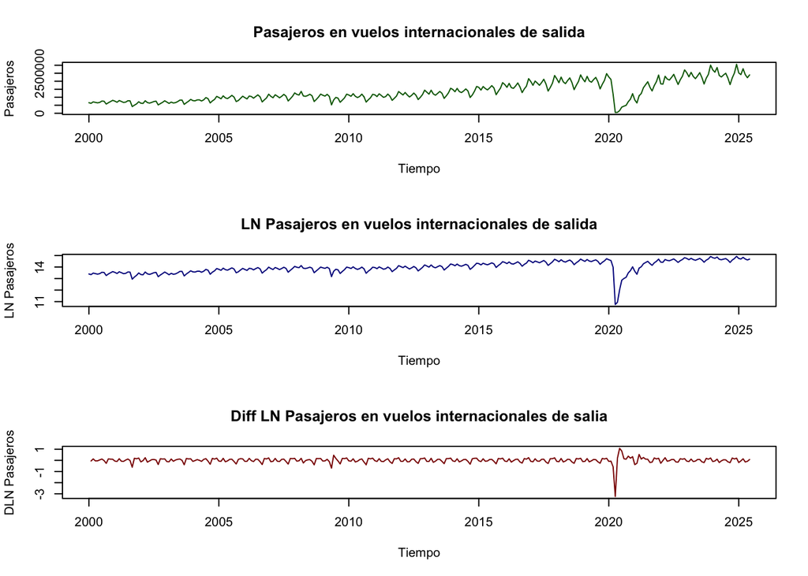